# Diabetes

## Background

I found the diabetes dataset from the National Institute of Diabetes & Digestive & Kidney Diseases. It was originally conducted to predict whether a patient had diabetes based on diagnostic measurements. The measurements they choose where number of pregnacies, plasma glucose concentration, blood pressure (mm Hg), Tricep skin fold thickness (mm), Insulin (mm U/ml), Body Mass Index, Diabetes pedigree function, age, and positive or negative diabetes results. The sample constituted females at least 21 years old of Pima Indian heritage. Thus, this dataset should not be used to generalize the whole American population. Nevertheless, we can discover useful information. I have heard often that insulin levels, glucose, and BMI affect risk of diabetes, but I have never heard of pregnancies associated with diabetes. Thus, I am curious to know: *Does the number of times an Pima Indian woman was pregnant affect the odds of her getting diabetes?*

### Null and Alternative Hypotheses

To answer this question, we will conduct a simple logistic regression. Since our explanatory variable is quantitative and our response variable is binomial and categorical (True or False that they have diabetes), then a simple logistic regression is more suitable to answer the question.

Our hypotheses are states as thus:

$$H_0:\beta_1=0$$
$$H_a:\beta_1 \neq 0$$

If $\beta_1=0$, then we would conclude that the number of times a Pima Indian woman was pregnant does not affect the odds of her getting diabetes. If $\beta_1 \neq 0$, then we would conclude that the number of pregnancies does affect the odds of Pima Indian women getting diabetes. Most likely it will be a positive relationship.

Our level of significance for our test will be $\alpha=0.05$.

### Logistic Regression

```r
diabetes.glm<-glm((outcome=="true")~pregnancies,data=diabetes,family=binomial)
summary(diabetes.glm) %>% pander()
```

|  | Estimate | Std. Error | z value | Pr(>\|z\|) |
| --- | --- | --- | --- | --- |
| **(Intercept)** | -1.177 | 0.1231 | -9.558 | 1.205e-21 |
| **pregnancies** | 0.1372 | 0.02291 | 5.986 | 2.147e-09 |

(Dispersion parameter for binomial family taken to be 1 )

| Null deviance: | 993.5 on 767 degrees of freedom |
| --- | --- |
| Residual deviance: | 956.2 on 766 degrees of freedom |

Since the P-value for $\beta_1$ is less than 0.05, we reject the null hypothesis. Therefore, there is sufficient evidence that pregnancy does affect the odds of a Pima woman having diabetes. The coefficient for $\beta_1$ in the above table does not mean much in this case, but $e^{\beta_1}$, which is part of logistic model, does. When we calculate $e^{0.1372}$, we get 1.1471. This means that the odds of having diabetes increases by a factor of 1.1471 for every 1 pregnancy increase. In other words, the odds of having diabetes increases by 14.71% for every 1 pregnancy increase.

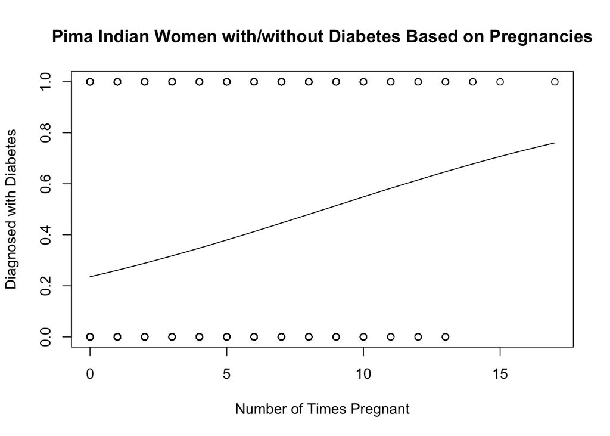

```r
b<-coef(diabetes.glm)
palette(c("seagreen","red2"))
plot((outcome=="true")~pregnancies,data=diabetes, main="Pima Indian Women with/without Diabetes Based on Pregnancies", xlab="Number of Times Pregnant", ylab="Diagnosed with Diabetes")
curve(exp(b[1]+b[2]*x)/(1+exp(b[1]+b[2]*x)),add=TRUE)
```

$Y_i=1$ means that the woman will have diabetes. $Y_i=0$ means that the woman will not have diabetes. There does not seem to be a strong logistical regression because both ends do not reach 0 and 1.

### Check Requirements

To check whether this logistical model is appropriate for the data, we need to test its goodness of it. There are two test we can use to determine this: Homer-Lemeshow Goodness-of-fit Test or the Deviance Goodness-of-fit Test. Our choice of test depends on the frequency of each x-value in our sample.

```r
table(diabetes$pregnancies) %>% pander()
```

| 0 | 1 | 2 | 3 | 4 | 5 | 6 | 7 | 8 | 9 | 10 | 11 | 12 | 13 | 14 | 15 | 17 |
| --- | --- | --- | --- | --- | --- | --- | --- | --- | --- | --- | --- | --- | --- | --- | --- | --- |
| 111 | 135 | 103 | 75 | 68 | 57 | 50 | 45 | 38 | 28 | 24 | 11 | 9 | 10 | 2 | 1 | 1 |

There are a few x-values that are repeat very frequently, and there are a few x-values that only have one occurrence in the sample. Since not all x-values repeat more than 50 times, we will use the Homer-Lemeshow Test for goodness of fit. Like other tests, this test has a null and alternative hypothesis. The null, in this case, is the logistical regression fits the data very well. The alternative would be the logistical regression does not fit the data very well. The level of significance is $\alpha=0.05$.

```r
hoslem.test(diabetes.glm$y,diabetes.glm$fitted,g=10) %>% pander()
```

Hosmer and Lemeshow goodness of fit (GOF) test: `diabetes.glm$y, diabetes.glm$fitted`

| Test statistic | df | P value |
| --- | --- | --- |
| 11.46 | 8 | 0.1771 |

### Prediction

Let’s say a Pima Indian woman has had 5 pregnancies. She wants to have another one. How are here odds that she will have diabetes with six pregnancies?

```r
predict(diabetes.glm,newdata=data.frame(pregnancies=6), type="response") %>% pander()
```

| 1 |
| --- |
| 0.4125 |

As we see, she has a 40% chance of having diabetes. It is something to arouse attention but not panic.